# Problem Statment :

# Open Businesses Which Are Restaurant :

```python
business_Open_Restaurants
```

|  | business_id | name | address | city | state | postal_code | latitude | longitude | stars | review_count | is_open | categories |
| --- | --- | --- | --- | --- | --- | --- | --- | --- | --- | --- | --- | --- |
| 0 | MTSW4McQd7CbVtyjqoe9mw | St Honore Pastries | 935 Race St | Philadelphia | PA | 19107 | 39.955505 | -75.155564 | 4.0 | 80 | 1 | Restaurants, Food, Bubble Tea, Coffee & Tea, B... |
| 1 | CF33F8-E6oudUQ46HnavjQ | Sonic Drive-In | 615 S Main St | Ashland City | TN | 37015 | 36.269593 | -87.058943 | 2.0 | 6 | 1 | Burgers, Fast Food, Sandwiches, Food, Ice Crea... |
| 2 | bBDDEgkFA1Otx9Lfe7BZUQ | Sonic Drive-In | 2312 Dickerson Pike | Nashville | TN | 37207 | 36.208102 | -86.768170 | 1.5 | 10 | 1 | Ice Cream & Frozen Yogurt, Fast Food, Burgers,... |
| 3 | eEOYSgkmpB90uNA7lDOMRA | Vietnamese Food Truck | None | Tampa Bay | FL | 33602 | 27.955269 | -82.456320 | 4.0 | 10 | 1 | Vietnamese, Food, Restaurants, Food Trucks |
| 4 | il_Ro8jwPlHresjw9EGmBg | Denny's | 8901 US 31 S | Indianapolis | IN | 46227 | 39.637133 | -86.127217 | 2.5 | 28 | 1 | American (Traditional), Restaurants, Diners, B... |
| ... | ... | ... | ... | ... | ... | ... | ... | ... | ... | ... | ... | ... |
| 34998 | sf_oQ62L8UEnOOLf00nNGA | Pizza Hut | 5028 Old Hickory | Hermitage | TN | 37076 | 36.193201 | -86.614748 | 3.0 | 6 | 1 | Restaurants, Pizza, Fast Food, Chicken Wings, ... |
| 35000 | l9eLGG9ZKpLJzboZq-9LRQ | Wawa | 19 N Bishop Ave | Clifton Heights | PA | 19018 | 39.925656 | -75.310344 | 3.0 | 11 | 1 | Restaurants, Sandwiches, Convenience Stores, C... |
| 35001 | cM6V90ExQD6KMSU3rRB5ZA | Dutch Bros Coffee | 1181 N Milwaukee St | Boise | ID | 83704 | 43.615401 | -116.284689 | 4.0 | 33 | 1 | Cafes, Juice Bars & Smoothies, Coffee & Tea, R... |
| 35002 | WnT9NIzQgLlILjPT0kEcsQ | Adelita Taqueria & Restaurant | 1108 S 9th St | Philadelphia | PA | 19147 | 39.935982 | -75.158665 | 4.5 | 35 | 1 | Restaurants, Mexican |
| 35003 | 2O2K6SXPWv56amqxCECd4w | The Plum Pit | 4405 Pennell Rd | Aston | DE | 19014 | 39.856185 | -75.427725 | 4.5 | 14 | 1 | Restaurants, Comfort Food, Food, Food Trucks, ... |

31537 rows × 12 columns

# Q. Which restaurant have the higest number of reviews ?

```python
pd.read_sql(""" select name, SUM(review_count) AS Higest_Review_Counts, AVG(stars) AS Average_Rating from (select * from business where is_open = 1 AND  lower(categories) like '%restaurant%') AS business_Open_Restaurants group by name order by Higest_Review_Counts desc limit 10;""",engine)
```

|  | name | Higest_Review_Counts | Average_Rating |
| --- | --- | --- | --- |
| 0 | McDonald's | 16490.0 | 1.868702 |
| 1 | Chipotle Mexican Grill | 9071.0 | 2.381757 |
| 2 | First Watch | 8688.0 | 3.896552 |
| 3 | Acme Oyster House | 8343.0 | 4.000000 |
| 4 | Taco Bell | 8017.0 | 2.141813 |
| 5 | Chick-fil-A | 7967.0 | 3.373418 |
| 6 | Oceana Grill | 7400.0 | 4.000000 |
| 7 | Buffalo Wild Wings | 6810.0 | 2.347458 |
| 8 | Panera Bread | 6613.0 | 2.661905 |
| 9 | Hattie B’s Hot Chicken - Nashville | 6093.0 | 4.500000 |

# Q. Which restaurant have the highest number of highest rating ?

```python
pd.read_sql(""" select name, SUM(review_count) AS Higest_Review_Counts, AVG(stars) AS Average_Rating from (select * from business where is_open = 1 AND  lower(categories) like '%restaurant%') AS business_Open_Restaurants group by name order by Average_Rating desc limit 10;""",engine).sort_values('Higest_Review_Counts',ascending=False)
```

|  | name | Higest_Review_Counts | Average_Rating |
| --- | --- | --- | --- |
| 7 | Vegan International Co. Kitchen & Market | 269.0 | 5.0 |
| 6 | The Foundry Bakery | 185.0 | 5.0 |
| 9 | Jet City Espresso Hyde Park | 152.0 | 5.0 |
| 1 | bb.q Chicken - O'Fallon | 42.0 | 5.0 |
| 3 | Asia Mix Restaurant | 10.0 | 5.0 |
| 5 | Healthy Soul Indy | 9.0 | 5.0 |
| 8 | Antojitos Carmen Restaurante Y Taqueria | 9.0 | 5.0 |
| 2 | Tacos Don Vicente | 8.0 | 5.0 |
| 0 | YWCA Corazon Cafe & Catering | 5.0 | 5.0 |
| 4 | In and Out Express Food Market | 5.0 | 5.0 |

## NOTE :

### No direct correlation: Higher rating do not guarantee a higher review count and vice versa, The review cannot reflect user engagement, but do not necessarily States the overall customer satisfaction or business performance, Successes in the restaurant business is not solely determined by rating or review counts.

# Q. Do restaurants with higer engagement tends to have higher rating ?

```python
pd.read_sql(""" select business_id, sum(length(date) - length(replace(date, ',', '')) + 1 ) as checkin_count from checkin group by business_id order by checkin_count desc ;""",engine)
```

|  | business_id | checkin_count |
| --- | --- | --- |
| 0 | 3wo9jODQnuvBm8Gkem6qXg | 3110.0 |
| 1 | MkF4gosEaJqJ3tNk1BZiwg | 3106.0 |
| 2 | ctHjyadbDQAtUFfkcAFEHw | 3104.0 |
| 3 | h6IzeUVASeDtvKhd2PEsKA | 3101.0 |
| 4 | 6dDC5PSmPEoJYuM8r8dN_A | 3096.0 |
| ... | ... | ... |
| 131718 | i5tex_2_UNEsPUh6oaVREA | 1.0 |
| 131719 | i6-xjNGY_8Co3DwHDrBZ4w | 1.0 |
| 131720 | i69x-7o4wuLbWC3sf4ek7Q | 1.0 |
| 131721 | i6n5Cv7C2OOfrgGAj5weiw | 1.0 |
| 131722 | i6nsOTszsTWJw_vRrBkAJg | 1.0 |

131723 rows × 2 columns

```python
# tip_counts per business_id
pd.read_sql(""" select business_id, count(*) as tip_counts from  tip group by business_id order by tip_counts desc;""",engine)
```

|  | business_id | tip_counts |
| --- | --- | --- |
| 0 | FEXhWNCMkv22qG04E83Qjg | 2571 |
| 1 | -QI8Qi8XWH3D8y8ethnajA | 1011 |
| 2 | _ab50qdWOk0DdB6XOrBitw | 932 |
| 3 | ytynqOUb3hjKeJfRj5Tshw | 827 |
| 4 | Eb1XmmLWyt_way5NNZ7-Pw | 826 |
| ... | ... | ... |
| 106188 | 54hp8YAMnI0baeSwbnBxDA | 1 |
| 106189 | GP9X_N5vMHYTuwcEiz-Xnw | 1 |
| 106190 | qgZtdbGuASSA-Av7_-rgCw | 1 |
| 106191 | H5TSeRUNkoCRtL2RcB9WKQ | 1 |
| 106192 | uE_4H__4kj4Xjb115_LBvA | 1 |

106193 rows × 2 columns

```python
review_counts = pd.read_sql(F""" select total.avg_rating as rating,
AVG(total.review_count) as avg_review_count,
AVG(total.checkin_count) as avg_checkin_count,
AVG(total.tip_count) as avg_tip_count
from
(select
    business.business_id,
    SUM(business.review_count) AS review_count,
    AVG(business.stars) AS avg_rating,
    SUM(LENGTH(checkin.date) - LENGTH(replace(checkin.date, ',', '')) +1) AS checkin_count,
    SUM(tip.tip_count) as tip_count
from
    business
left join
    checkin ON business.business_id = checkin.business_id
left join
    (select business_id, count(business_id) as tip_count from tip GROUP BY business_id ORDER BY tip_count) as tip ON business.business_id = tip.business_id
where business.business_id IN {tuple(business_Open_Restaurants['business_id'])}
GROUP BY
    business.business_id) as total
GROUP BY total.avg_rating
 """,engine)
```

```python
review_counts=review_counts.sort_values('rating', ascending=False)
```

# Ploting `Bar` Graphs :

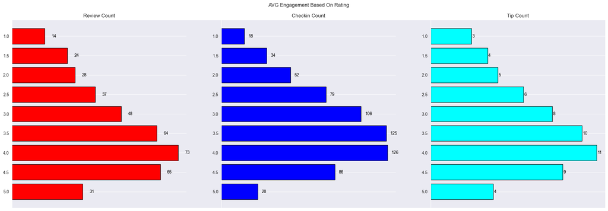

```python
# Creating Void and Axis for ploting the graphs
plt.figure(figsize=(25,8))
plt.title('AVG Engagement Based On Rating\n\n')
plt.xticks([])
plt.yticks([])

# Review Count Plot
plt.subplot(1,3,1)
plt.title('Review Count')
plt.barh(review_counts['rating'].astype('str'), review_counts['avg_review_count'], edgecolor= 'k', color = 'RED')
plt.gca().spines['right'].set_visible(False)
for i, value in enumerate(review_counts['avg_review_count']):
    plt.text(value+3,i,str(round(value)), color='Black', va = 'center')
plt.xticks([])

# Checkin Count Plot
plt.subplot(1,3,2)
plt.title('Checkin Count')
plt.barh(review_counts['rating'].astype('str'), review_counts['avg_checkin_count'], edgecolor= 'k', color = 'BLUE')
plt.gca().spines['right'].set_visible(False)
for i, value in enumerate(review_counts['avg_checkin_count']):
    plt.text(value+3,i,str(round(value)), color='Black', va = 'center')
plt.xticks([])

# Tip Count Plot
plt.subplot(1,3,3)
plt.title('Tip Count')
plt.barh(review_counts['rating'].astype('str'), review_counts['avg_tip_count'], edgecolor= 'k', color = 'CYAN')
plt.gca().spines['right'].set_visible(False)
for i, value in enumerate(review_counts['avg_tip_count']):
    plt.text(value+0.05,i,str(round(value)), color='Black', va = 'center')
plt.xticks([])
plt.show()
```

## NOTE :

### Data show a general increase in average review check in and tip counts as rating improves from one to four stars, restaurants created four stars. Exhibit the highest engagement across reviews, check insurance and tips, suggesting a peak in user interaction, interestingly, engagement matrix. ( Review, check in ). Dip for restaurant rated 4.5 and significantly more at five stars, They dropped an engagement at 5 stars might suggest either a situation point where fewer customer feel compended or to add their reviews for a selective believer only a small satisfied audience. Frequents these establishment.

# Q. Is there a correclation between the number of reviews, tip, and check - ins for a business ?

```python
engage_df = pd.read_sql(F""" select business.business_id,
 sum(business.review_count) as review_count,
 AVG(business.stars) as avg_rating,
 SUM(LENGTH(checkin.date) - LENGTH(replace(checkin.date, ',', '')) +1) as checkin_count,
 SUM(tip.tip_count) as tip_count
 from
 business
 left join
    checkin ON business.business_id = checkin.business_id
left join
    (select business_id, count(business_id) as tip_count from tip GROUP BY business_id ORDER BY tip_count) as tip ON business.business_id = tip.business_id
where business.business_id IN {tuple(business_Open_Restaurants['business_id'])}
GROUP BY
    business.business_id


 """,engine).dropna()
```

```python
engage_df_corr = engage_df[['review_count','checkin_count','tip_count']].corr()
```

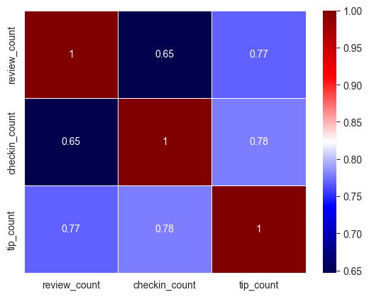

```python
# Ploting the HeatMap
sns.heatmap(engage_df_corr,cmap='seismic', annot=True, linewidths=0.5,linecolor='white')
```

```python
engage_dff = pd.read_sql(F"""
    SELECT
        business.business_id,
        SUM(business.review_count) AS review_count,
        AVG(business.stars) AS avg_rating,
        SUM(LENGTH(checkin.date) - LENGTH(REPLACE(checkin.date, ',', '')) + 1) AS checkin_count,
        SUM(tip.tip_count) AS tip_count,
        CASE
            WHEN business.stars >= 3.5 THEN 'High-Rated'
            ELSE 'Low-Rated'
        END AS category
    FROM
        business
    LEFT JOIN
        checkin ON business.business_id = checkin.business_id
    LEFT JOIN
        (SELECT business_id, COUNT(business_id) AS tip_count
         FROM tip
         GROUP BY business_id) AS tip ON business.business_id = tip.business_id
    WHERE
        business.business_id IN {tuple(business_Open_Restaurants['business_id'])}
    GROUP BY
        business.business_id, business.stars
""", engine).dropna()
```

```python
engage_dff.groupby('category')[['review_count','tip_count','checkin_count']].mean()
```

| category | review_count | tip_count | checkin_count |
| --- | --- | --- | --- |
| High-Rated | 72.274446 | 10.148378 | 121.375576 |
| Low-Rated | 42.123420 | 6.541689 | 88.880828 |

## NOTE :

### The data set shows a strong positive correlation among review counts, checking counts and tip counts, These correlations suggest that user engagement across different platforms, such as reviews, tips and check insurance is interlinked, Higher activity in one area tends to be associated with higher activity others. Businesses should focus on strategies that boost all types of user investment as increases in one type of engagement are likely to drive increase in others. And hence, in overall visibility and interaction with customers.

```python
# Function to calculate the sucess score based on the avg rating and total review count.
def calculate_sucess_metric(df):
    sucess_score=[]
    for idx, row in df.iterrows():
        score = row['avg_rating'] * np.log(row['review_count'] + 1 )
        sucess_score.append(score)
    return sucess_score
```

# MAP Plot :

# Q. How do the sucess metrics (review_count or avg_rating) of restaurant vary across different states and cities?

```python
city_df = pd.read_sql(F"""
SELECT
    city,
    state,
    latitude,
    longitude,
    AVG(stars) AS avg_rating,
    SUM(review_count) AS review_count,
    COUNT(*) AS restaurant_count
FROM business
WHERE business_id IN {tuple(business_Open_Restaurants['business_id'])}
GROUP BY state, city, latitude, longitude
ORDER BY review_count DESC
LIMIT 10
""", engine)
```

```python
city_df = city_df.reset_index()
```

```python
city_df = city_df.drop('index',axis = 1)
```

```python
city_df['success_score'] = calculate_sucess_metric(city_df)
```

```python
city_df
```

|  | city | state | latitude | longitude | avg_rating | review_count | restaurant_count | success_score |
| --- | --- | --- | --- | --- | --- | --- | --- | --- |
| 0 | Philadelphia | PA | 39.953159 | -75.159098 | 4.000000 | 541.0 | 6 | 25.181064 |
| 1 | Nashville | TN | 36.163685 | -86.782598 | 4.000000 | 517.0 | 3 | 24.999901 |
| 2 | Carmel | IN | 39.978599 | -86.128981 | 4.166667 | 503.0 | 3 | 25.927401 |
| 3 | Sparks | NV | 39.541452 | -119.716242 | 3.000000 | 452.0 | 4 | 18.347676 |
| 4 | Hendersonville | TN | 36.302820 | -86.619056 | 4.375000 | 431.0 | 4 | 26.549362 |
| 5 | Nashville | TN | 36.170064 | -86.665561 | 3.625000 | 424.0 | 4 | 21.938823 |
| 6 | Nashville | TN | 36.138603 | -86.800358 | 4.000000 | 417.0 | 2 | 24.141926 |
| 7 | Philadelphia | PA | 39.958359 | -75.195393 | 4.250000 | 416.0 | 6 | 25.640616 |
| 8 | Indianapolis | IN | 39.858230 | -85.978565 | 4.250000 | 411.0 | 2 | 25.589349 |
| 9 | Philadelphia | PA | 39.949756 | -75.148062 | 3.583333 | 379.0 | 12 | 21.285614 |

```python
# Create a base Map
m = folium.Map(location = [city_df['latitude'].mean(), city_df['longitude'].mean()], zoom_start = 4)

# Define a color scale
color_scale = folium.LinearColormap(colors=['green','yellow','#E54F29'], vmin = city_df['success_score'].min(), vmax = city_df['success_score'].max())

# Add markers to the map

for idx, row in city_df.iterrows():
    folium.CircleMarker(
        location = [row['latitude'], row['longitude']],
        radius = 5,
        color = color_scale(row['success_score']),
        fill = True,
        fill_color = color_scale(row['success_score']),
        fill_opacity = 0.7,
        popup=F"Success Score: {row ['success_score']}"
    ).add_to(m)

# Add color scale to the map

m.add_child(color_scale)
```

Make this Notebook Trusted to load map: File -> Trust Notebook

[interactive chart not shown]

## NOTE :

# Time :

# Q. Are there any patterns in the user engagement over time for sucessfull business compared to less sucessfull ones, Are there any seasonal trends in the user engagement for restaurant ?

```python
high_rated_engagement = pd.read_sql_query(f"""
SELECT review.month_year, review.review_count, tip.tip_count FROM
(SELECT DATE_FORMAT(date, '%m-%Y') AS month_year, COUNT(*) AS review_count
FROM review
WHERE business_id IN {tuple(business_Open_Restaurants['business_id'])} AND stars >= 3.5
GROUP BY month_year
ORDER BY month_year) AS review
JOIN
(SELECT AVG(b.stars) AS avg_stars, DATE_FORMAT(tip.date, '%m-%Y') AS month_year, COUNT(*) AS tip_count
FROM tip
JOIN business AS b
ON tip.business_id = b.business_id
WHERE tip.business_id IN {tuple(business_Open_Restaurants['business_id'])} AND b.stars >= 3.5
GROUP BY month_year
ORDER BY month_year) AS tip
ON review.month_year = tip.month_year
;""", engine)

low_rated_engagement = pd.read_sql_query(f"""
SELECT review.month_year, review.review_count, tip.tip_count FROM
(SELECT DATE_FORMAT(date, '%m-%Y') AS month_year, COUNT(*) AS review_count
FROM review
WHERE business_id IN {tuple(business_Open_Restaurants['business_id'])} AND stars < 3.5
GROUP BY month_year
ORDER BY month_year) AS review
JOIN
(SELECT AVG(b.stars) AS avg_stars, DATE_FORMAT(tip.date, '%m-%Y') AS month_year, COUNT(*) AS tip_count
FROM tip
JOIN business AS b
ON tip.business_id = b.business_id
WHERE tip.business_id IN {tuple(business_Open_Restaurants['business_id'])} AND b.stars < 3.5
GROUP BY month_year
ORDER BY month_year) AS tip
ON review.month_year = tip.month_year
;""", engine)
```

```python
high_rated_engagement
```

|  | month_year | review_count | tip_count |
| --- | --- | --- | --- |
| 0 | 01-2010 | 1218 | 79 |
| 1 | 01-2011 | 2171 | 621 |
| 2 | 01-2012 | 3086 | 1321 |
| 3 | 01-2013 | 3801 | 1230 |
| 4 | 01-2014 | 4973 | 1357 |
| ... | ... | ... | ... |
| 149 | 12-2017 | 10161 | 1477 |
| 150 | 12-2018 | 12870 | 1163 |
| 151 | 12-2019 | 13756 | 1161 |
| 152 | 12-2020 | 11294 | 937 |
| 153 | 12-2021 | 12652 | 652 |

154 rows × 3 columns

```python
low_rated_engagement
```

|  | month_year | review_count | tip_count |
| --- | --- | --- | --- |
| 0 | 01-2010 | 613 | 25 |
| 1 | 01-2011 | 1103 | 297 |
| 2 | 01-2012 | 1748 | 538 |
| 3 | 01-2013 | 2196 | 548 |
| 4 | 01-2014 | 2769 | 607 |
| ... | ... | ... | ... |
| 149 | 12-2017 | 5970 | 441 |
| 150 | 12-2018 | 7574 | 338 |
| 151 | 12-2019 | 7591 | 275 |
| 152 | 12-2020 | 5014 | 148 |
| 153 | 12-2021 | 6937 | 122 |

154 rows × 3 columns

```python
time_rating = pd.read_sql(f"""
SELECT DATE_FORMAT(date, '%m-%Y') AS month_year, AVG(stars) AS avg_rating
FROM review
WHERE business_id IN {tuple(business_Open_Restaurants['business_id'])}
GROUP BY month_year
ORDER BY month_year;
""", engine)
```

```python
time_rating
```

|  | month_year | avg_rating |
| --- | --- | --- |
| 0 | 01-2006 | 4.000000 |
| 1 | 01-2007 | 3.897436 |
| 2 | 01-2008 | 3.603960 |
| 3 | 01-2009 | 3.690661 |
| 4 | 01-2010 | 3.724194 |
| ... | ... | ... |
| 198 | 12-2017 | 3.613415 |
| 199 | 12-2018 | 3.608687 |
| 200 | 12-2019 | 3.665246 |
| 201 | 12-2020 | 3.833701 |
| 202 | 12-2021 | 3.672673 |

203 rows × 2 columns

```python
# time_rating
time_rating['month_year'] = pd.to_datetime(time_rating['month_year'])
time_rating.sort_values('month_year',inplace= True)
time_rating = time_rating[time_rating['month_year']>'2017']

# high_rated_engagement
high_rated_engagement['month_year'] = pd.to_datetime(high_rated_engagement['month_year'])
high_rated_engagement.sort_values('month_year',inplace=True)
high_rated_engagement = high_rated_engagement[high_rated_engagement['month_year']>'2017']

# low_rated_engagement
low_rated_engagement['month_year'] =  pd.to_datetime(low_rated_engagement['month_year'])
low_rated_engagement.sort_values('month_year',inplace=True)
low_rated_engagement = low_rated_engagement[low_rated_engagement['month_year']>'2017']
```

```python
# Creating a col called avg_rating in high_rated_engagement
high_rated_engagement['avg_rating'] = time_rating['avg_rating'].values
```

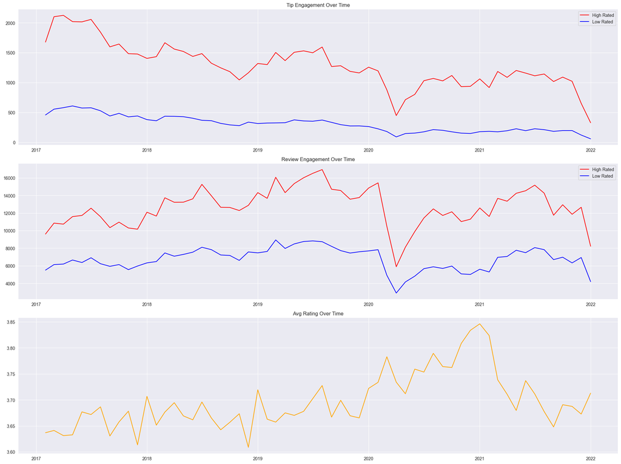

```python
# ploting the time trends
plt.figure(figsize=(20, 15))
plt.subplot(3,1,1)
plt.title('Tip Engagement Over Time')
plt.plot(high_rated_engagement['month_year'], high_rated_engagement['tip_count'], label = 'High Rated', color = 'RED')
plt.plot(low_rated_engagement['month_year'], low_rated_engagement['tip_count'], label = 'Low Rated', color = 'BLUE')
plt.legend()

plt.subplot(3,1,2)
plt.title('Review Engagement Over Time')
plt.plot(high_rated_engagement['month_year'], high_rated_engagement['review_count'], label = 'High Rated', color = 'RED')
plt.plot(low_rated_engagement['month_year'], low_rated_engagement['review_count'], label = 'Low Rated', color = 'BLUE')
plt.legend()

plt.subplot(3,1,3)
plt.title('Avg Rating Over Time')
plt.plot(time_rating['month_year'], time_rating['avg_rating'], color = 'ORANGE')
plt.tight_layout()
plt.show()
```

```python
tip_high_rated = high_rated_engagement[['month_year','tip_count']].set_index('month_year')
review_high_rated = high_rated_engagement[['month_year', 'review_count']].set_index('month_year')
rating_df = time_rating[['month_year', 'avg_rating']].set_index('month_year')
```

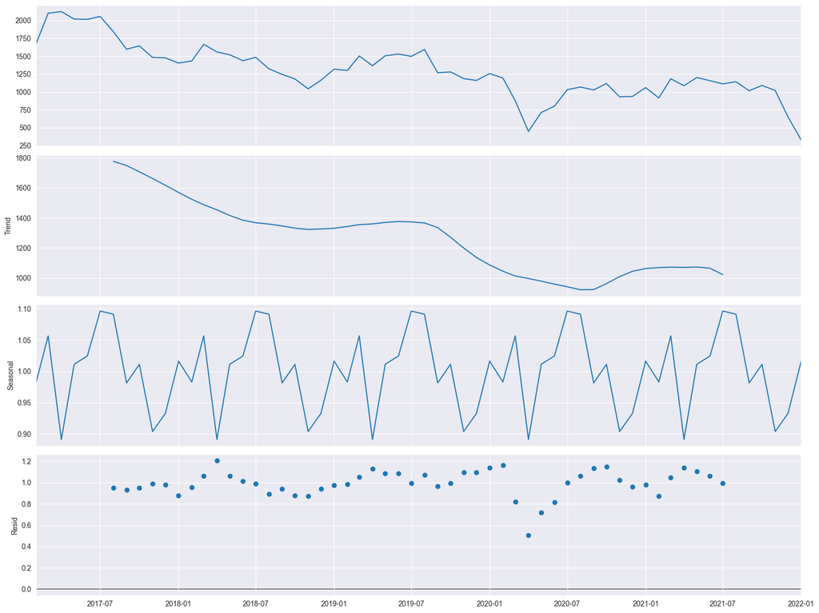

```python
# seasonal_decompose of tip_high_rated
from statsmodels.tsa.seasonal import seasonal_decompose
multiplication_decompose = seasonal_decompose(tip_high_rated, model = 'multiplication', period = 12)
plt.rcParams.update({'figure.figsize':(16,12)})
multiplication_decompose.plot()
plt.show()
```

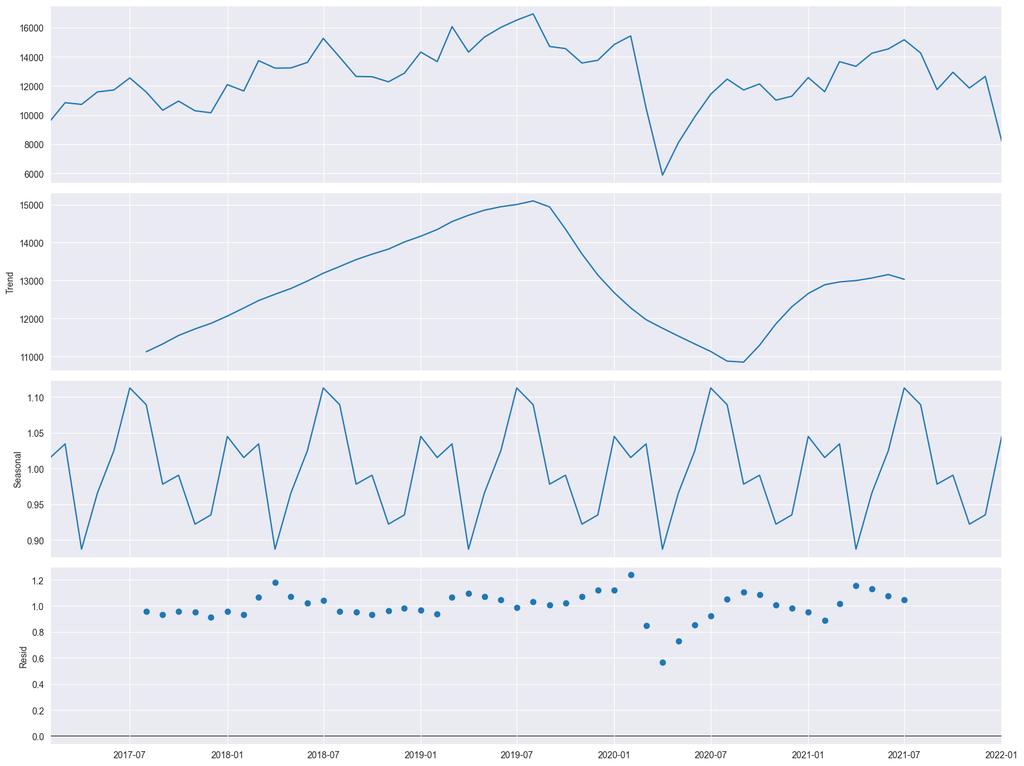

```python
# seasonal_decompose of  review_high_rated
from statsmodels.tsa.seasonal import seasonal_decompose
multiplication_decompose = seasonal_decompose(review_high_rated, model = 'multiplication', period = 12)
plt.rcParams.update({'figure.figsize':(16,12)})
multiplication_decompose.plot()
plt.show()
```

## NOTE :

# Sentiment Analysis Using NLTK :

# Q. Retrive Top Five Restaurant with High Success Score And Sentiments Included ( Positive, Negetive & Neutral )

```python
# import nltk
# from nltk.sentiment import SentimentIntensityAnalyzer
#
# # Create a sentiment col
# sentiment = review['text']
#
# # Perform sentiment analysis using SentimentIntensityAnalyzer:
#
# sia = SentimentIntensityAnalyzer()
#
# # Define a function to get sentiment score
# def get_sentiment(comment):
#     score = sia.polarity_scores(comment)
#     return score['compound']  # compound score for overall sentiment
#
# # Apply sentiment analysis to the 'comments' column
# sentiment_score = sentiment.apply(get_sentiment)
# sentiments = sentiment_score.apply(lambda x: 'Positive' if x > 0 else ('Negative' if x < 0 else 'Neutral'))
#
# sentiments
```

```python
sentim = pd.read_csv('D:\\VSCODE\\SQL_PROJECT\\Senti.csv')
```

```python
senti = pd.concat([review[['business_id','text']], sentim], axis = 1)
```

```python
# Sentiments
senti
```

|  | business_id | text | Unnamed: 0.1 | Unnamed: 0 | text |
| --- | --- | --- | --- | --- | --- |
| 0 | XQfwVwDr-v0ZS3_CbbE5Xw | If you decide to eat here, just be aware it is... | 0 | 0 | Positive |
| 1 | 7ATYjTIgM3jUlt4UM3IypQ | I've taken a lot of spin classes over the year... | 1 | 1 | Positive |
| 2 | YjUWPpI6HXG530lwP-fb2A | Family diner. Had the buffet. Eclectic assortm... | 2 | 2 | Positive |
| 3 | kxX2SOes4o-D3ZQBkiMRfA | Wow! Yummy, different, delicious. Our favo... | 3 | 3 | Positive |
| 4 | e4Vwtrqf-wpJfwesgvdgxQ | Cute interior and owner (?) gave us tour of up... | 4 | 4 | Positive |
| ... | ... | ... | ... | ... | ... |
| 6990275 | jals67o91gcrD4DC81Vk6w | Latest addition to services from ICCU is Apple... | 6990275 | 6990275 | Negative |
| 6990276 | 2vLksaMmSEcGbjI5gywpZA | This spot offers a great, affordable east week... | 6990276 | 6990276 | Positive |
| 6990277 | R1khUUxidqfaJmcpmGd4aw | This Home Depot won me over when I needed to g... | 6990277 | 6990277 | Positive |
| 6990278 | Rr9kKArrMhSLVE9a53q-aA | For when I'm feeling like ignoring my calorie-... | 6990278 | 6990278 | Positive |
| 6990279 | VAeEXLbEcI9Emt9KGYq9aA | Located in the 'Walking District' in Nashville... | 6990279 | 6990279 | Positive |

6990280 rows × 5 columns

```python
business
```

|  | business_id | name | address | city | state | postal_code | latitude | longitude | stars | review_count | is_open | categories |
| --- | --- | --- | --- | --- | --- | --- | --- | --- | --- | --- | --- | --- |
| 0 | Pns2l4eNsfO8kk83dixA6A | Abby Rappoport, LAC, CMQ | 1616 Chapala St, Ste 2 | Santa Barbara | CA | 93101 | 34.426679 | -119.711197 | 5.0 | 7 | 0 | Doctors, Traditional Chinese Medicine, Naturop... |
| 1 | mpf3x-BjTdTEA3yCZrAYPw | The UPS Store | 87 Grasso Plaza Shopping Center | Affton | MO | 63123 | 38.551126 | -90.335695 | 3.0 | 15 | 1 | Shipping Centers, Local Services, Notaries, Ma... |
| 2 | tUFrWirKiKi_TAnsVWINQQ | Target | 5255 E Broadway Blvd | Tucson | AZ | 85711 | 32.223236 | -110.880452 | 3.5 | 22 | 0 | Department Stores, Shopping, Fashion, Home & G... |
| 3 | MTSW4McQd7CbVtyjqoe9mw | St Honore Pastries | 935 Race St | Philadelphia | PA | 19107 | 39.955505 | -75.155564 | 4.0 | 80 | 1 | Restaurants, Food, Bubble Tea, Coffee & Tea, B... |
| 4 | mWMc6_wTdE0EUBKIGXDVfA | Perkiomen Valley Brewery | 101 Walnut St | Green Lane | PA | 18054 | 40.338183 | -75.471659 | 4.5 | 13 | 1 | Brewpubs, Breweries, Food |
| ... | ... | ... | ... | ... | ... | ... | ... | ... | ... | ... | ... | ... |
| 150341 | IUQopTMmYQG-qRtBk-8QnA | Binh's Nails | 3388 Gateway Blvd | Edmonton | AB | T6J 5H2 | 53.468419 | -113.492054 | 3.0 | 13 | 1 | Nail Salons, Beauty & Spas |
| 150342 | c8GjPIOTGVmIemT7j5_SyQ | Wild Birds Unlimited | 2813 Bransford Ave | Nashville | TN | 37204 | 36.115118 | -86.766925 | 4.0 | 5 | 1 | Pets, Nurseries & Gardening, Pet Stores, Hobby... |
| 150343 | _QAMST-NrQobXduilWEqSw | Claire's Boutique | 6020 E 82nd St, Ste 46 | Indianapolis | IN | 46250 | 39.908707 | -86.065088 | 3.5 | 8 | 1 | Shopping, Jewelry, Piercing, Toy Stores, Beaut... |
| 150344 | mtGm22y5c2UHNXDFAjaPNw | Cyclery & Fitness Center | 2472 Troy Rd | Edwardsville | IL | 62025 | 38.782351 | -89.950558 | 4.0 | 24 | 1 | Fitness/Exercise Equipment, Eyewear & Optician... |
| 150345 | jV_XOycEzSlTx-65W906pg | Sic Ink | 238 Apollo Beach Blvd | Apollo beach | FL | 33572 | 27.771002 | -82.394910 | 4.5 | 9 | 1 | Beauty & Spas, Permanent Makeup, Piercing, Tattoo |

150346 rows × 12 columns

```python
business_data = business[['business_id','name']]
senti = senti.iloc[:,[0,4]]
```

```python
senti
```

|  | business_id | text |
| --- | --- | --- |
| 0 | XQfwVwDr-v0ZS3_CbbE5Xw | Positive |
| 1 | 7ATYjTIgM3jUlt4UM3IypQ | Positive |
| 2 | YjUWPpI6HXG530lwP-fb2A | Positive |
| 3 | kxX2SOes4o-D3ZQBkiMRfA | Positive |
| 4 | e4Vwtrqf-wpJfwesgvdgxQ | Positive |
| ... | ... | ... |
| 6990275 | jals67o91gcrD4DC81Vk6w | Negative |
| 6990276 | 2vLksaMmSEcGbjI5gywpZA | Positive |
| 6990277 | R1khUUxidqfaJmcpmGd4aw | Positive |
| 6990278 | Rr9kKArrMhSLVE9a53q-aA | Positive |
| 6990279 | VAeEXLbEcI9Emt9KGYq9aA | Positive |

6990280 rows × 2 columns

```python
real_sentiments = pd.merge(business_data,senti, how='inner', on= ['business_id'])
```

```python
real_sentiments
```

|  | business_id | name | text |
| --- | --- | --- | --- |
| 0 | Pns2l4eNsfO8kk83dixA6A | Abby Rappoport, LAC, CMQ | Positive |
| 1 | Pns2l4eNsfO8kk83dixA6A | Abby Rappoport, LAC, CMQ | Positive |
| 2 | Pns2l4eNsfO8kk83dixA6A | Abby Rappoport, LAC, CMQ | Positive |
| 3 | Pns2l4eNsfO8kk83dixA6A | Abby Rappoport, LAC, CMQ | Positive |
| 4 | Pns2l4eNsfO8kk83dixA6A | Abby Rappoport, LAC, CMQ | Positive |
| ... | ... | ... | ... |
| 6990275 | jV_XOycEzSlTx-65W906pg | Sic Ink | Positive |
| 6990276 | jV_XOycEzSlTx-65W906pg | Sic Ink | Positive |
| 6990277 | jV_XOycEzSlTx-65W906pg | Sic Ink | Positive |
| 6990278 | jV_XOycEzSlTx-65W906pg | Sic Ink | Positive |
| 6990279 | jV_XOycEzSlTx-65W906pg | Sic Ink | Negative |

6990280 rows × 3 columns

```python
real_sentiments = real_sentiments.groupby(['business_id','name','text']).value_counts()
```

```python
real_sentiments_df = real_sentiments.reset_index()
```

```python
#Success_Business
success_business = pd.read_sql(F"""
SELECT
    business_id, name,
    AVG(stars) AS avg_rating,
    SUM(review_count) AS review_count,
    COUNT(*) AS restaurant_count
FROM business
WHERE business_id IN {tuple(business_Open_Restaurants['business_id'])}
GROUP BY business_id, name
ORDER BY review_count DESC
""", engine)
```

```python
success_business
```

|  | business_id | name | avg_rating | review_count | restaurant_count |
| --- | --- | --- | --- | --- | --- |
| 0 | wPQWqLxY6t3-yRBNPPAmkQ | Shallos Antique Restaurant & Brewhouse | 4.0 | 248.0 | 1 |
| 1 | y8gjlpJA89qDRCLC0JQaew | Giuseppe & Sons | 4.0 | 248.0 | 1 |
| 2 | gkZ6iiEfnO7I2UzOHbkzrA | Ulysses American Gastro Pub | 3.5 | 248.0 | 1 |
| 3 | 98WBvrn7wzu_93zc7fRfzQ | Vero Amore - Dove | 4.0 | 248.0 | 1 |
| 4 | 30OhTA38fp8xuqW4O2D6Eg | Homegrown Taproom & Kitchen | 4.0 | 248.0 | 1 |
| ... | ... | ... | ... | ... | ... |
| 31532 | 3xoCPDgE5dEretLD4yFpRw | The Juice Pod | 2.5 | 5.0 | 1 |
| 31533 | nPruiFveAtUcGrUbFBeQuQ | Bark Busters Dog Home Training | 4.0 | 5.0 | 1 |
| 31534 | Hk_EjFDeK5u7rlYEUx6a_g | Jaggie's Restaurant | 3.0 | 5.0 | 1 |
| 31535 | qv6TSnK4iXZAXxG13mjv-w | Angelina's Panini Bar | 2.0 | 5.0 | 1 |
| 31536 | rwZ-1fH9vdh1KRAowovXOQ | Subway | 3.5 | 5.0 | 1 |

31537 rows × 5 columns

```python
success_business['Success_score'] = calculate_sucess_metric(success_business)
```

```python
success_business
```

|  | business_id | name | avg_rating | review_count | restaurant_count | Success_score |
| --- | --- | --- | --- | --- | --- | --- |
| 0 | wPQWqLxY6t3-yRBNPPAmkQ | Shallos Antique Restaurant & Brewhouse | 4.0 | 248.0 | 1 | 22.069812 |
| 1 | y8gjlpJA89qDRCLC0JQaew | Giuseppe & Sons | 4.0 | 248.0 | 1 | 22.069812 |
| 2 | gkZ6iiEfnO7I2UzOHbkzrA | Ulysses American Gastro Pub | 3.5 | 248.0 | 1 | 19.311085 |
| 3 | 98WBvrn7wzu_93zc7fRfzQ | Vero Amore - Dove | 4.0 | 248.0 | 1 | 22.069812 |
| 4 | 30OhTA38fp8xuqW4O2D6Eg | Homegrown Taproom & Kitchen | 4.0 | 248.0 | 1 | 22.069812 |
| ... | ... | ... | ... | ... | ... | ... |
| 31532 | 3xoCPDgE5dEretLD4yFpRw | The Juice Pod | 2.5 | 5.0 | 1 | 4.479399 |
| 31533 | nPruiFveAtUcGrUbFBeQuQ | Bark Busters Dog Home Training | 4.0 | 5.0 | 1 | 7.167038 |
| 31534 | Hk_EjFDeK5u7rlYEUx6a_g | Jaggie's Restaurant | 3.0 | 5.0 | 1 | 5.375278 |
| 31535 | qv6TSnK4iXZAXxG13mjv-w | Angelina's Panini Bar | 2.0 | 5.0 | 1 | 3.583519 |
| 31536 | rwZ-1fH9vdh1KRAowovXOQ | Subway | 3.5 | 5.0 | 1 | 6.271158 |

31537 rows × 6 columns

```python
success_business = success_business.sort_values('Success_score',ascending=False)
```

```python
success_business
```

|  | business_id | name | avg_rating | review_count | restaurant_count | Success_score |
| --- | --- | --- | --- | --- | --- | --- |
| 204 | bjQrmBSu1A7f5vprEikOKA | Healthy N Fresh Cafe | 5.0 | 238.0 | 1 | 27.382318 |
| 399 | S5LnH1njwFBlq77tIkjI1g | Yolk White & Associates | 5.0 | 229.0 | 1 | 27.190397 |
| 508 | emrUsUZvqCkytUu4i3kjLw | Sundae's Ice Cream & Coffee | 5.0 | 225.0 | 1 | 27.102675 |
| 557 | 0I9XZD7JTqY9iTF8nXRnXw | Ali'i Poke Indy | 5.0 | 223.0 | 1 | 27.058230 |
| 611 | jh8j-DWqgWkbRe_a2XtKFQ | Barrio Bread | 5.0 | 221.0 | 1 | 27.013387 |
| ... | ... | ... | ... | ... | ... | ... |
| 31139 | Q4OTSH9DaoeqtYcg6qYtZg | Subway | 1.0 | 5.0 | 1 | 1.791759 |
| 30725 | F6zk6xPTLQZFdA0hu6nLgA | Hungry Howie's Pizza & Subs | 1.0 | 5.0 | 1 | 1.791759 |
| 31157 | BJ0Z74sTz9sxRr1R533Inw | Best Rate Home Services | 1.0 | 5.0 | 1 | 1.791759 |
| 30715 | ogoe6WcXJnW96rvc3NyMfw | Burger King | 1.0 | 5.0 | 1 | 1.791759 |
| 31362 | 2HLZfbL-6lcr9jhriW6GeA | Subway Restaurants | 1.0 | 5.0 | 1 | 1.791759 |

31537 rows × 6 columns

```python
real_sentiments_df
```

|  | business_id | name | text | count |
| --- | --- | --- | --- | --- |
| 0 | ---kPU91CF4Lq2-WlRu9Lw | Frankie's Raw Bar | Negative | 1 |
| 1 | ---kPU91CF4Lq2-WlRu9Lw | Frankie's Raw Bar | Positive | 23 |
| 2 | --0iUa4sNDFiZFrAdIWhZQ | Pupuseria Y Restaurant Melba | Negative | 3 |
| 3 | --0iUa4sNDFiZFrAdIWhZQ | Pupuseria Y Restaurant Melba | Positive | 11 |
| 4 | --30_8IhuyMHbSOcNWd6DQ | Action Karate | Negative | 4 |
| ... | ... | ... | ... | ... |
| 351933 | zzu6_r3DxBJuXcjnOYVdTw | Cafe Diblasi | Positive | 7 |
| 351934 | zzw66H6hVjXQEt0Js3Mo4A | Sullivan Farms Christmas Trees | Negative | 1 |
| 351935 | zzw66H6hVjXQEt0Js3Mo4A | Sullivan Farms Christmas Trees | Positive | 4 |
| 351936 | zzyx5x0Z7xXWWvWnZFuxlQ | Walnut Street Pizza | Negative | 3 |
| 351937 | zzyx5x0Z7xXWWvWnZFuxlQ | Walnut Street Pizza | Positive | 5 |

351938 rows × 4 columns

```python
main_sentiment_df = pd.merge(real_sentiments_df,success_business, how='inner',on=['business_id','name']).sort_values(['Success_score'],ascending=False)
```

```python
main_sentiment_df.sort_values('count',ascending=False)
main_sentiment_df
```

|  | business_id | name | text | count | avg_rating | review_count | restaurant_count | Success_score |
| --- | --- | --- | --- | --- | --- | --- | --- | --- |
| 50059 | bjQrmBSu1A7f5vprEikOKA | Healthy N Fresh Cafe | Positive | 234 | 5.0 | 238.0 | 1 | 27.382318 |
| 50058 | bjQrmBSu1A7f5vprEikOKA | Healthy N Fresh Cafe | Neutral | 1 | 5.0 | 238.0 | 1 | 27.382318 |
| 50057 | bjQrmBSu1A7f5vprEikOKA | Healthy N Fresh Cafe | Negative | 5 | 5.0 | 238.0 | 1 | 27.382318 |
| 36579 | S5LnH1njwFBlq77tIkjI1g | Yolk White & Associates | Positive | 219 | 5.0 | 229.0 | 1 | 27.190397 |
| 36577 | S5LnH1njwFBlq77tIkjI1g | Yolk White & Associates | Negative | 7 | 5.0 | 229.0 | 1 | 27.190397 |
| ... | ... | ... | ... | ... | ... | ... | ... | ... |
| 31365 | NxB8M1wnJQ5xoXDiUgqmIg | Burger King | Neutral | 1 | 1.0 | 5.0 | 1 | 1.791759 |
| 34051 | Q4OTSH9DaoeqtYcg6qYtZg | Subway | Negative | 4 | 1.0 | 5.0 | 1 | 1.791759 |
| 19745 | ESUwN81iNYvm0yqYCxSivg | Jack in the Box | Negative | 2 | 1.0 | 5.0 | 1 | 1.791759 |
| 19746 | ESUwN81iNYvm0yqYCxSivg | Jack in the Box | Positive | 3 | 1.0 | 5.0 | 1 | 1.791759 |
| 3476 | 1dpjXnlEKc-Ihgku6CtY5w | Little Caesars Pizza Barataria Blvd | Positive | 3 | 1.0 | 5.0 | 1 | 1.791759 |

80616 rows × 8 columns

```python
# Top Five Highest Sucess Score Restaurant
main_sentiment_df.head(14)[['name']].drop_duplicates('name').sort_values('name').values
```

```
array([["Ali'i Poke Indy"],
       ['Barrio Bread'],
       ['Healthy N Fresh Cafe'],
       ["Sundae's Ice Cream & Coffee"],
       ['Yolk White & Associates']], dtype=object)
```

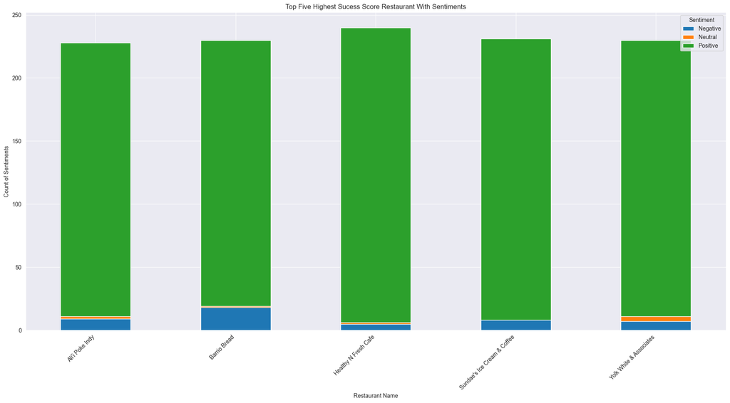

```python
# Pivot the DataFrame to prepare for stacked bar plot
pivot_df = main_sentiment_df.head(14).pivot_table(index='name', columns='text', values='count', fill_value=0)

# Plot Stacked Bar
pivot_df.plot(kind='bar', stacked=True, figsize=(18, 10))
plt.title('Top Five Highest Sucess Score Restaurant With Sentiments')
plt.xlabel('Restaurant Name')
plt.ylabel('Count of Sentiments')
plt.xticks(rotation=45, ha='right')
plt.legend(title='Sentiment')
plt.tight_layout()
plt.show()
```

## NOTE :

### There are top five highest success score restaurants, including not only the higher rating and higher review counts, but also having a higher positive sentiments In compare to the other negative and neutral sentiments. These five restaurant may be the best restaurants in overall comparison.

# Distribution Of Data Based On Elite And Non ELite :

# Q. Is there any difference in engagement of elite users and non-elite users?

```python
elite_df = pd.read_sql("""
    SELECT
        elite,
        COUNT(*) AS num_users,
        SUM(review_count) AS total_review_count
    FROM (
        SELECT
            CASE
                WHEN elite = 'None' OR elite = '' OR elite IS NUll THEN 'Not Elite'
                ELSE 'Elite'
            END AS elite,
            user.review_count
        FROM
            user
    ) AS user_elite
    GROUP BY
        elite;
""", engine)
```

```python
# Elite
elite_df
```

|  | elite | num_users | total_review_count |
| --- | --- | --- | --- |
| 0 | Elite | 90969 | 20450520.0 |
| 1 | Not Elite | 1892854 | 25963868.0 |

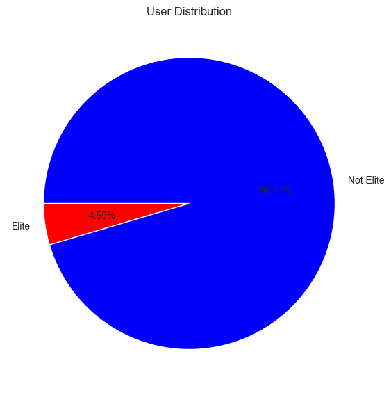

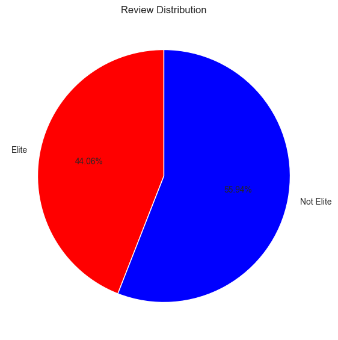

```python
# Pie Plot of User Distribution
plt.figure(figsize=(10,15))
plt.subplot(2,1,1)
plt.title('User Distribution')
plt.pie(elite_df['num_users'],labels = elite_df['elite'], autopct = '%0.2f%%', startangle= 180, colors = ['RED', 'BLUE'])

# Pie Plot of Review Distribution
plt.figure(figsize=(10,15))
plt.subplot(2,1,2)
plt.title('Review Distribution')
plt.pie(elite_df['total_review_count'],labels = elite_df['elite'], autopct = '%0.2f%%', startangle= 90, colors = ['RED', 'BLUE'])
plt.show()
```

## NOTE :

### `Elite` users are individual who have been recognized and awarded the `Elite` status by the Yelp and their active and high quality contribution to the platform, such as frequent and detailed review photos and check insurance. Among the others criteria. `Elite` users despite being significant fewer in numbers, contributed a substantial proportion of the total account compared to the non-elite users. `Elite` users often provide detailed and insightful reviews, which can influence other users perceptions and decision regarding a business. review from `Elite` users may receive more attention and visibility on the real platform due to their status potentially leading to the higher exposure through business.Establishing a positive relationship with `Elite` users can lead a repeat visit and loyalty, as they have more likely to continue supporting widgets they have had good experience with.

# Time Based Analysis :

## Q. What are the busiest hours for restaurants ?

```python
review_engagement = pd.read_sql_query("""
SELECT
    HOUR(STR_TO_DATE(date, '%Y-%m-%d %H:%i:%s')) AS hour,
    COUNT(*) AS review_count
FROM review
GROUP BY hour;
""", engine)

tip_engagement = pd.read_sql_query("""
SELECT
    HOUR(STR_TO_DATE(date, '%Y-%m-%d %H:%i:%s')) AS hour,
    COUNT(*) AS tip_count
FROM tip
GROUP BY hour;
""", engine)

checkin = pd.read_sql_query("SELECT date FROM checkin", engine)
checkin_engagement = []

for i in checkin['date']:
    checkin_engagement.extend(
        [datetime.strptime(j.strip(), "%Y-%m-%d %H:%M:%S").strftime("%H")
         for j in i.split(',')]
    )

checkin_engagement = pd.DataFrame(checkin_engagement).astype(int).groupby(0)[0].count()
```

```python
checkin_engagement.name = 'Values'
checkin_engagement
```

```
0
0     1060009
1      853147
2      602632
3      388609
4      233305
5      133875
6       74652
7       46172
8       30390
9       29614
10      51960
11     100839
12     180490
13     267501
14     368108
15     532775
16     794471
17     924978
18     900055
19     833639
20     775722
21     827312
22     984501
23    1109237
Name: Values, dtype: int64
```

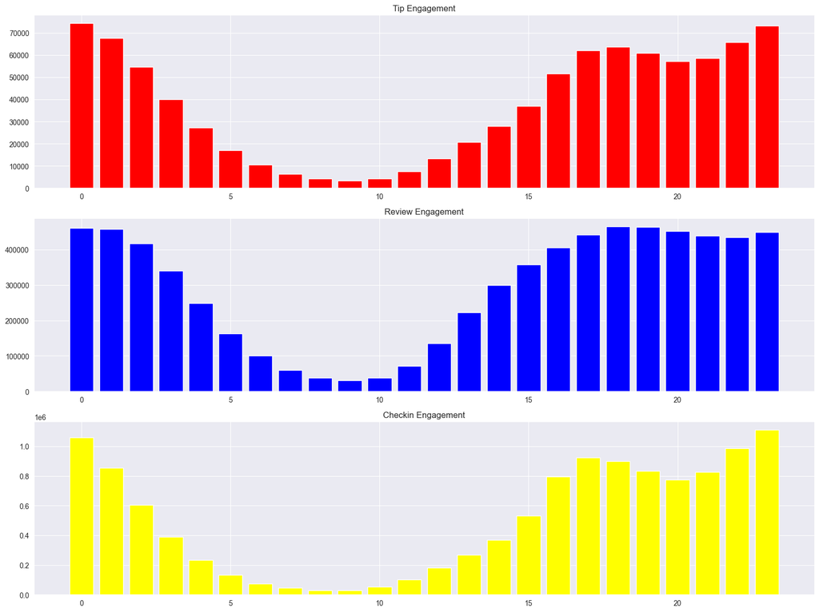

```python
# Bar Plot
# tip_engagement
plt.subplot(3,1,1)
plt.title("Tip Engagement")
plt.bar(tip_engagement['hour'], tip_engagement['tip_count'], color = 'RED')

# review_engagement
plt.subplot(3,1,2)
plt.title("Review Engagement")
plt.bar(review_engagement['hour'], review_engagement['review_count'], color = 'BLUE')

# Checkin Engagement
plt.subplot(3,1,3)
plt.title("Checkin Engagement")
plt.bar(checkin_engagement.index, checkin_engagement  , color = 'YELLOW')
plt.tight_layout()
plt.show()
```

## NOTE :

### The busiest R4 restaurants based on user engagement spanned from 3:00 PM to 1:00 AM, Knowing the peak hours allowed businesses to optimize their staffing level and resources accolation allocation during the during this. time to ensure defensiency of resident and quality service delivery. The concentration of user engagement during the evening and night hours suggest a higher demand for dining out, dining these times potentially driven by the factor such as work schedules, Social gathering and leisure activities.

# RECOMMENDATIONS :

### 1. Utilizing inssights from the analysis of various metrics such as user engagement, sentiment of reviews, peak hours, and the impact of eilte users, businesses can make informed decisions to drive sucess.

### 2. Collaborating With light users and leveraging their influence can amplify proportional efforts, increase brand awareness and the drive customer acquisition.

### 3. Businesses can adjust their operating hours or introduce special promotions to capitalize on increased demand during peak hours.

### 4. Less successful businesses may need to focus on strategies to enhance user engagement over time, such as improving service quality responding to customer feedback.

### 5. Cities with high success scores presents opportunities for restaurant chains to expand or invest further.

### 6. Understanding customer preferences behavior and satisfaction level is paramount. Businesses should focus on delivery exponential experience to meet customer expectations.

### 7. Positive reviews from Elite users and high user engagement can boost a business online visibility and reputation. Maintaining an active engagement with customers and responding promptly to feedback is crucial for building credibility and attracting a new customers.